# Final DA Exam — 36-401

Further Diagnostics: Residuals

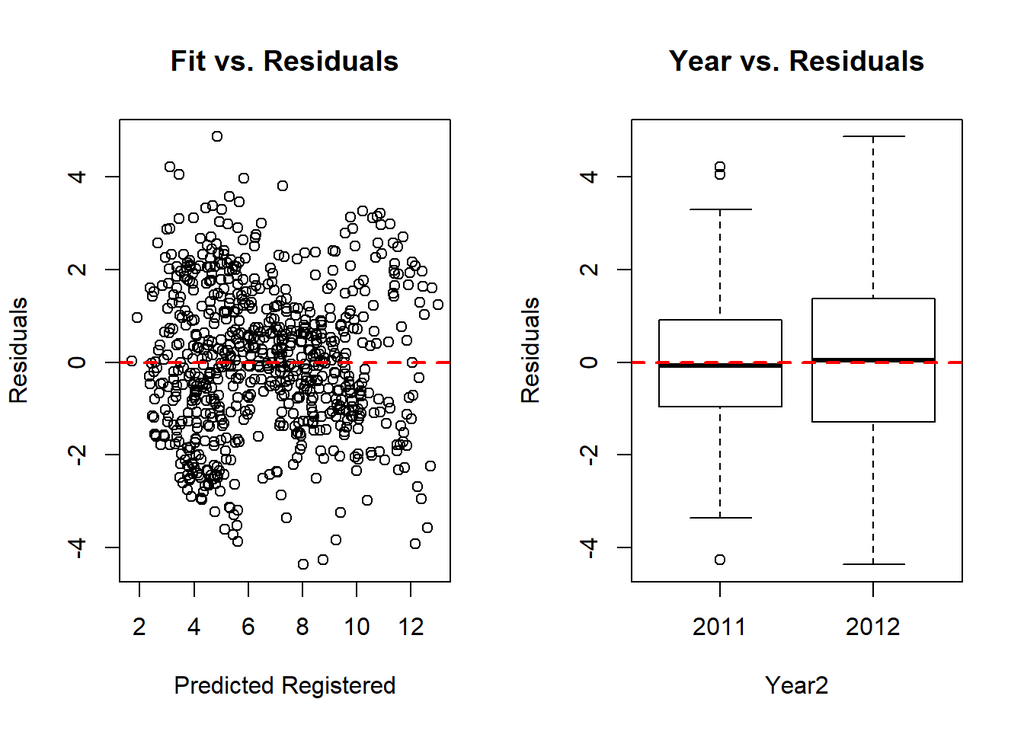

```r
par(mfrow = c(1,2))
plot(mod4.1$fitted.values, mod4.1$residuals,main = "Fit vs. Residuals", xlab= "Predicted Registered", ylab= "Residuals")
abline(h=0,lty=2, col = "red", lwd = 2)

boxplot(mod4.1$res~Year2,names=c(2011,2012),ylab="Residuals", main = "Year vs. Residuals")
abline(h=0,lty=2, col = "red", lwd = 2)
```

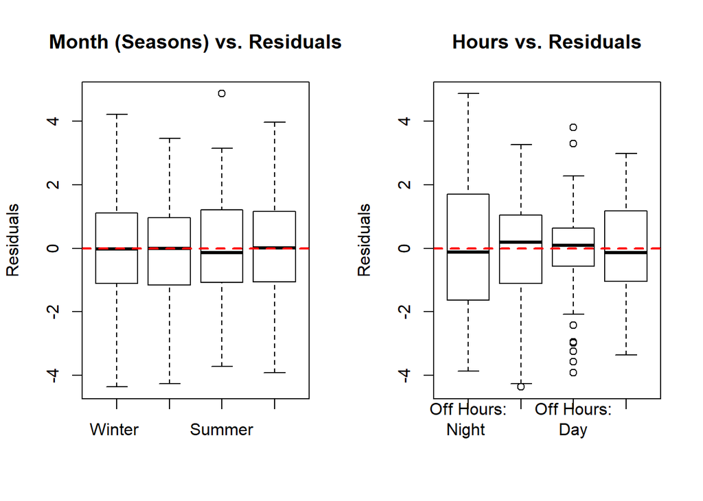

```r
boxplot(mod4.1$res[Winter2==1],mod4.1$res[Spring2==1],mod4.1$res[Summer2==1],mod4.1$res[Fall2==1],names=c("Winter ","Spring","Summer","Fall"),ylab="Residuals");
title("Month (Seasons) vs. Residuals")
abline(h=0,lty=2, lwd= 2, col = "red")

boxplot(mod4.1$res[OffHours.Night2==1],mod4.1$res[RushHour.Day2==1],mod4.1$res[OffHours.Day2==1],mod4.1$res[RushHour.Night2==1],names=c("Off Hours:\nNight ","Rush Hours:\nDay","Off Hours:\nDay","Rush Hours:\nNight"),ylab="Residuals");
title("Hours vs. Residuals")
abline(h=0,lty=2, lwd= 2, col = "red")
```

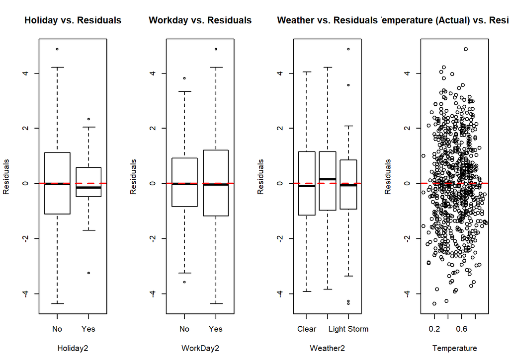

```r
par(mfrow = c(1,4))
boxplot(mod4.1$res~Holiday2,names=c("No","Yes"),ylab="Residuals", main = "Holiday vs. Residuals")
abline(h=0,lty=2, col = "red", lwd = 2)

boxplot(mod4.1$res~WorkDay2,names=c("No","Yes"),ylab="Residuals", main = "Workday vs. Residuals")
abline(h=0,lty=2, col = "red", lwd = 2)

boxplot(mod4.1$res~Weather2,names=c("Clear","Cloudy","Light Storm"),ylab="Residuals", main = "Weather vs. Residuals")
abline(h=0,lty=2, col = "red", lwd = 2)

plot(Temp2,mod4.1$residuals, main = "Temperature (Actual) vs. Residuals", xlab = "Temperature", ylab = "Residuals")
abline(h=0,lty=2, col = "red", lwd = 2)
```

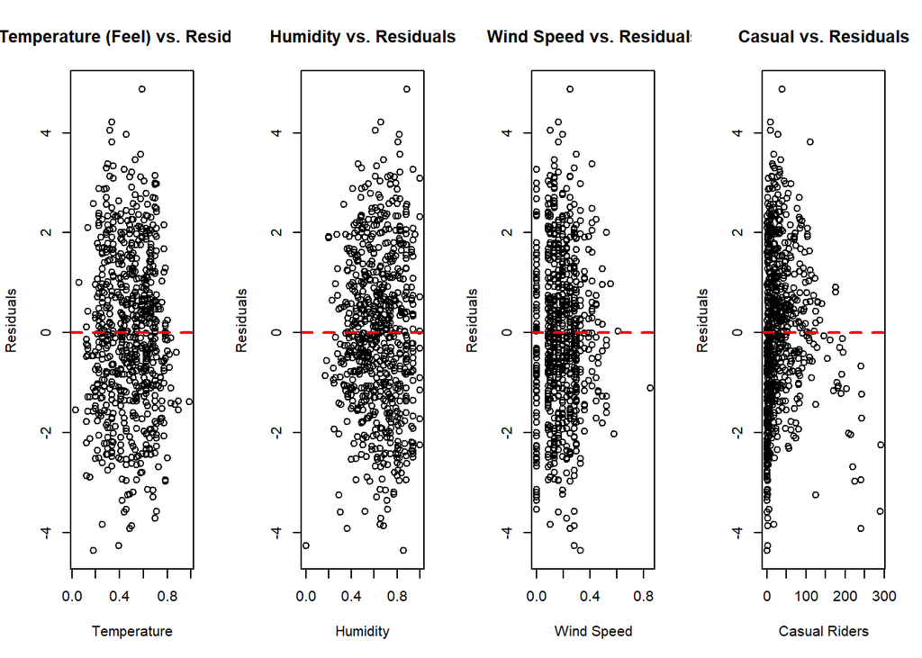

```r
plot(TempFeel2,mod4.1$residuals, main = "Temperature (Feel) vs. Residuals", xlab = "Temperature", ylab = "Residuals")
abline(h=0,lty=2, col = "red", lwd = 2)

plot(Humidity2,mod4.1$residuals, main = "Humidity vs. Residuals", xlab = "Humidity", ylab = "Residuals")
abline(h=0,lty=2, col = "red", lwd = 2)

plot(Windspeed2,mod4.1$residuals, main = "Wind Speed vs. Residuals", xlab = "Wind Speed", ylab = "Residuals")
abline(h=0,lty=2, col = "red", lwd = 2)

plot(Casual2,mod4.1$residuals, main = "Casual vs. Residuals", xlab = "Casual Riders", ylab = "Residuals")
abline(h=0,lty=2, col = "red", lwd = 2)
```

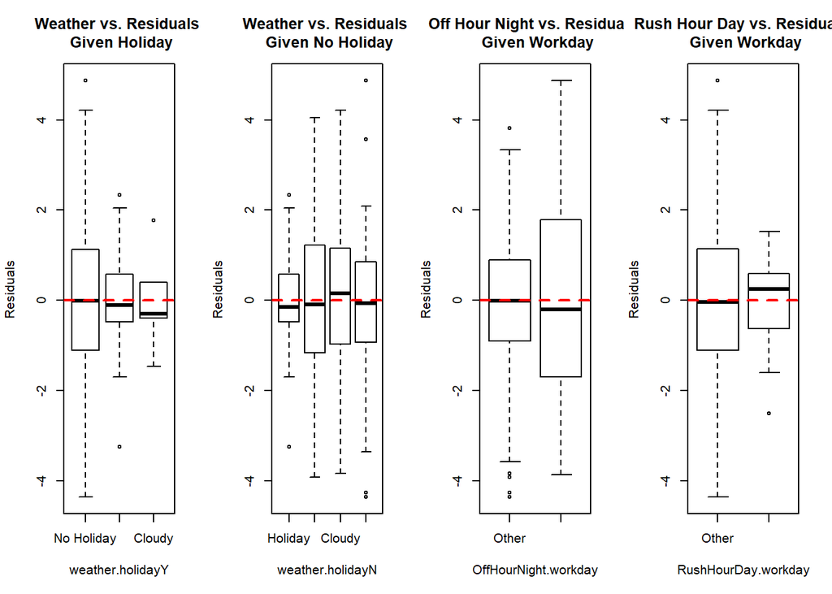

```r
weather.holidayY = Weather2*ifelse(Holiday2 == 1,1,0)
weather.holidayN = Weather2*ifelse(Holiday2 == 0,1,0)
boxplot(mod4.1$residuals~weather.holidayY, main = "Weather vs. Residuals \n Given Holiday", ylab= "Residuals", names = c("No Holiday", "Clear","Cloudy"))
abline(h=0,lty=2, col = "red", lwd = 2)
boxplot(mod4.1$residuals~weather.holidayN, main = "Weather vs. Residuals \n Given No Holiday", ylab= "Residuals",names = c("Holiday", "Clear","Cloudy", "Light Storm"))
abline(h=0,lty=2, col = "red", lwd = 2)

OffHourNight.workday = ifelse(WorkDay2 == 1,1,0)*OffHours.Night2
RushHourDay.workday = ifelse(WorkDay2 == 0,1,0)*RushHour.Day2
OffHourDay.workday = ifelse(WorkDay2 == 1,1,0)*OffHours.Day2
RushHourNight.workday = ifelse(WorkDay2 == 0,1,0)*RushHour.Night2

boxplot(mod4.1$residuals~OffHourNight.workday, main = "Off Hour Night vs. Residuals \n Given Workday", ylab= "Residuals", names = c("Other", "Workday/\nOff Hour Night"))
abline(h=0,lty=2, col = "red", lwd = 2)
boxplot(mod4.1$residuals~RushHourDay.workday, main = "Rush Hour Day vs. Residuals \n Given Workday", ylab= "Residuals", names = c("Other", "Workday/\nRush Hour Day"))
abline(h=0,lty=2, col = "red", lwd = 2)
```

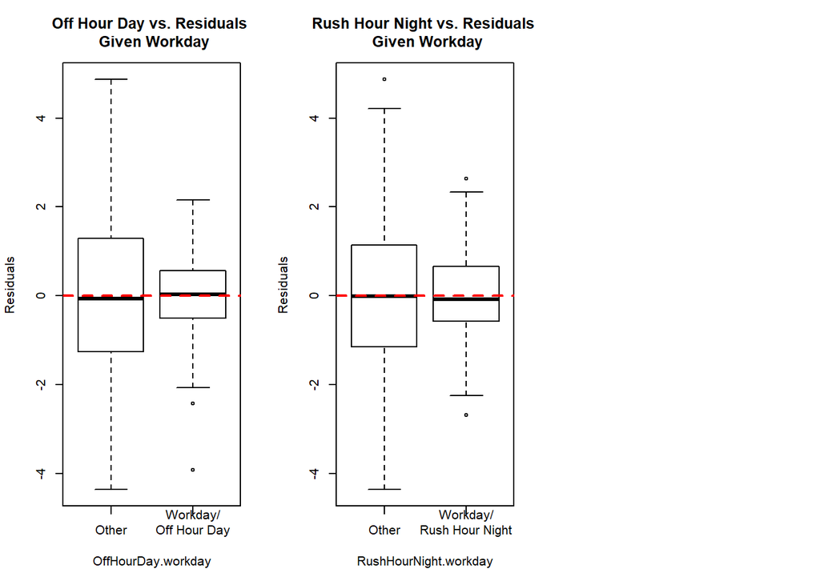

```r
par(mfrow = c(1,3))
boxplot(mod4.1$residuals~OffHourDay.workday, main = "Off Hour Day vs. Residuals \n Given Workday", ylab= "Residuals", names = c("Other", "Workday/\nOff Hour Day"))
abline(h=0,lty=2, col = "red", lwd = 2)
boxplot(mod4.1$residuals~RushHourNight.workday, main = "Rush Hour Night vs. Residuals \n Given Workday", ylab= "Residuals", names = c("Other", "Workday/\nRush Hour Night"))
abline(h=0,lty=2, col = "red", lwd = 2)
```

Generally: Negative resids still more spread out. But constant variance. Due to more frequent negative outliers. Humidity: More stratified in higher Windspeed: One outlier with high windspeed. No need for transformation. Casual: Many 0’s and gradually spread. Higher days, negative residuals. But lack of data. Interaction terms: Expectation residual zero some sort of an issue. Goes back to its individual resid issues.

Further Diagnostics: Independence

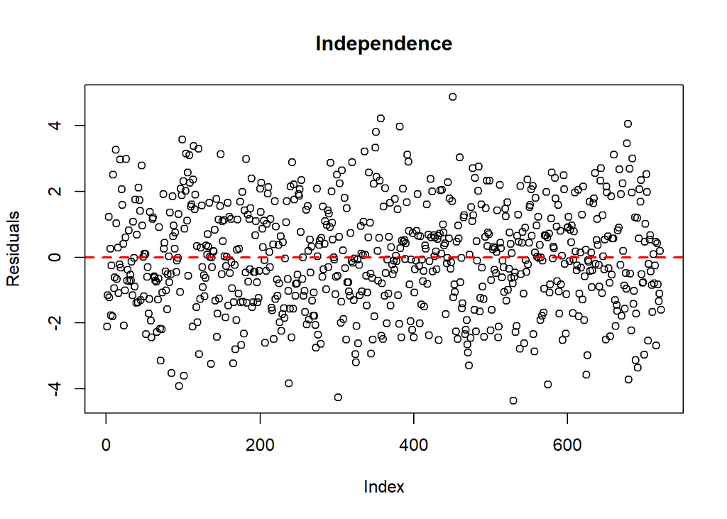

```r
plot(mod4.1$residuals,xlab= "Index",ylab="Residuals", main="Independence")
abline(h=0,lty=2,lwd=2, col= "red")
```

Good. No pattern.

Final Model Analysis:

```r
#Model 5: Variable Transformation
par(mfrow = c(1,1))
Casual3 = log(Casual2+1)
mod5.1 = lm(registered3~as.factor(Year2)+Spring2+Summer2+Fall2+RushHour.Day2+OffHours.Day2+RushHour.Night2+as.factor(Holiday2)+as.factor(WorkDay2)+Weather2+Temp2+TempFeel2+Humidity2+Windspeed2+Casual3+Weather2*as.factor(Holiday2)+as.factor(WorkDay2)*RushHour.Day2+as.factor(WorkDay2)*OffHours.Day2+as.factor(WorkDay2)*RushHour.Night2)
summary(mod5.1)
```

```
##
## Call:
## lm(formula = registered3 ~ as.factor(Year2) + Spring2 + Summer2 +
##     Fall2 + RushHour.Day2 + OffHours.Day2 + RushHour.Night2 +
##     as.factor(Holiday2) + as.factor(WorkDay2) + Weather2 + Temp2 +
##     TempFeel2 + Humidity2 + Windspeed2 + Casual3 + Weather2 *
##     as.factor(Holiday2) + as.factor(WorkDay2) * RushHour.Day2 +
##     as.factor(WorkDay2) * OffHours.Day2 + as.factor(WorkDay2) *
##     RushHour.Night2)
##
## Residuals:
##     Min      1Q  Median      3Q     Max
## -4.9580 -0.8871 -0.0543  0.7744  3.5206
##
## Coefficients:
##                                      Estimate Std. Error t value Pr(>|t|)
## (Intercept)                           1.53908    0.31914   4.823 1.74e-06
## as.factor(Year2)2012                  0.86287    0.10109   8.535  < 2e-16
## Spring2                              -0.26322    0.17051  -1.544 0.123108
## Summer2                              -0.08088    0.23371  -0.346 0.729393
## Fall2                                 0.34963    0.17069   2.048 0.040902
## RushHour.Day2                        -0.16070    0.28917  -0.556 0.578571
## OffHours.Day2                         0.69457    0.26374   2.634 0.008637
## RushHour.Night2                       1.00538    0.26112   3.850 0.000129
## as.factor(Holiday2)1                 -0.19414    0.83187  -0.233 0.815541
## as.factor(WorkDay2)1                  0.83139    0.17505   4.749 2.47e-06
## Weather2                             -0.19970    0.08741  -2.285 0.022629
## Temp2                                 0.22463    2.14506   0.105 0.916629
## TempFeel2                            -0.51331    2.34129  -0.219 0.826526
## Humidity2                            -0.13207    0.36336  -0.363 0.716366
## Windspeed2                           -0.14879    0.44722  -0.333 0.739465
## Casual3                               1.35991    0.06198  21.940  < 2e-16
## as.factor(Holiday2)1:Weather2        -0.16847    0.65867  -0.256 0.798203
## RushHour.Day2:as.factor(WorkDay2)1    3.94145    0.33259  11.851  < 2e-16
## OffHours.Day2:as.factor(WorkDay2)1   -0.53429    0.27221  -1.963 0.050064
## RushHour.Night2:as.factor(WorkDay2)1  2.09243    0.29030   7.208 1.47e-12
##
## (Intercept)                          ***
## as.factor(Year2)2012                 ***
## Spring2
```

[output cut: 8 more lines]

```
## Temp2
## TempFeel2
## Humidity2
## Windspeed2
## Casual3                              ***
## as.factor(Holiday2)1:Weather2
## RushHour.Day2:as.factor(WorkDay2)1   ***
## OffHours.Day2:as.factor(WorkDay2)1   .
## RushHour.Night2:as.factor(WorkDay2)1 ***
## ---
## Signif. codes:  0 '***' 0.001 '**' 0.01 '*' 0.05 '.' 0.1 ' ' 1
##
## Residual standard error: 1.3 on 702 degrees of freedom
## Multiple R-squared:  0.823,  Adjusted R-squared:  0.8182
## F-statistic: 171.8 on 19 and 702 DF,  p-value: < 2.2e-16
```

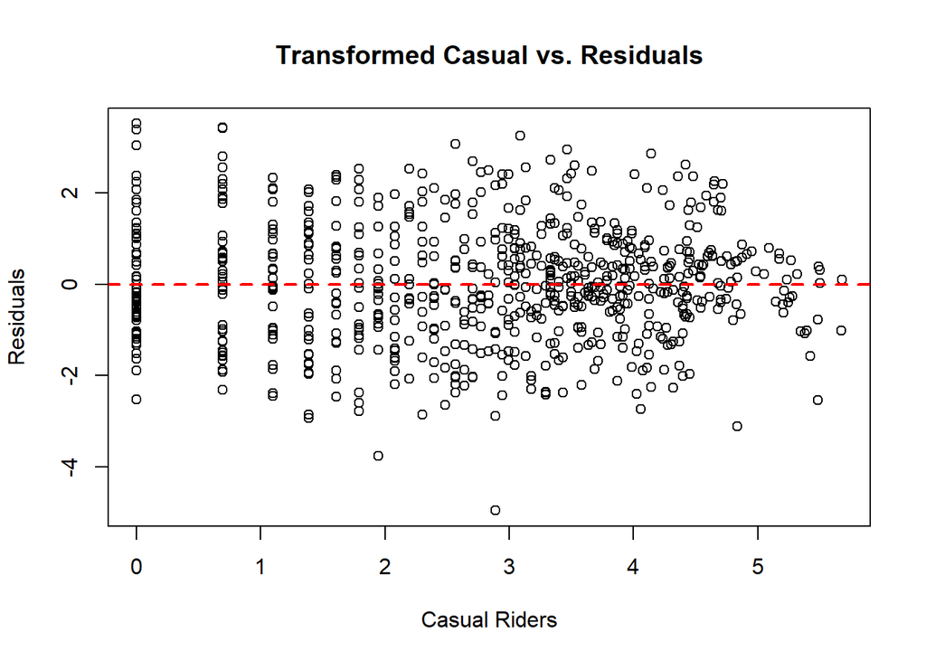

```r
plot(Casual3,mod5.1$residuals, main = "Transformed Casual vs. Residuals", xlab = "Casual Riders", ylab = "Residuals")
abline(h=0,lty=2, col = "red", lwd = 2)
```

```r
'plot(Windspeed2, mod5.1$residuals)
Windspeed3 = log(Windspeed2+1)
plot(Windspeed3, mod5.1$residuals)

mod5.2 = lm(registered3~as.factor(Year2)+Spring2+Summer2+Fall2+as.factor(Hour2)+as.factor(Holiday2)+as.factor(WorkDay2)+Weather2+Temp2+TempFeel2+Humidity2+Windspeed3+Casual3+Weather2*as.factor(Holiday2)+as.factor(WorkDay2)*as.factor(Hour2))
summary(mod5.2)'
```

```
## [1] "plot(Windspeed2, mod5.1$residuals)\nWindspeed3 = log(Windspeed2+1)\nplot(Windspeed3, mod5.1$residuals)\n\nmod5.2 = lm(registered3~as.factor(Year2)+Spring2+Summer2+Fall2+as.factor(Hour2)+as.factor(Holiday2)+as.factor(WorkDay2)+Weather2+Temp2+TempFeel2+Humidity2+Windspeed3+Casual3+Weather2*as.…
```

```r
#Model 6: Variable Removal
mod6.1 = lm(registered3~as.factor(Year2)+Spring2+Summer2+Fall2+RushHour.Day2+OffHours.Day2+RushHour.Night2+as.factor(Holiday2)+as.factor(WorkDay2)+Weather2+Casual3+Weather2*as.factor(Holiday2)+as.factor(WorkDay2)*RushHour.Day2+as.factor(WorkDay2)*OffHours.Day2+as.factor(WorkDay2)*RushHour.Night2+Temp2+TempFeel2+Humidity2+Windspeed2)
aov(mod6.1)
```

```
## Call:
##    aov(formula = mod6.1)
##
## Terms:
##                 as.factor(Year2)   Spring2   Summer2     Fall2
## Sum of Squares          266.2447    3.1825  152.7481  324.2121
## Deg. of Freedom                1         1         1         1
##                 RushHour.Day2 OffHours.Day2 RushHour.Night2
## Sum of Squares       487.6172      316.5899       2236.3826
## Deg. of Freedom             1             1               1
##                 as.factor(Holiday2) as.factor(WorkDay2)  Weather2
## Sum of Squares              19.1269             85.9495  109.8898
## Deg. of Freedom                   1                   1         1
##                   Casual3     Temp2 TempFeel2 Humidity2 Windspeed2
## Sum of Squares  1152.2733    7.9414    0.9219    0.0497     0.2999
## Deg. of Freedom         1         1         1         1          1
##                 as.factor(Holiday2):Weather2
## Sum of Squares                        0.8368
## Deg. of Freedom                            1
##                 RushHour.Day2:as.factor(WorkDay2)
## Sum of Squares                           227.3350
## Deg. of Freedom                                 1
##                 OffHours.Day2:as.factor(WorkDay2)
## Sum of Squares                            41.9293
## Deg. of Freedom                                 1
##                 RushHour.Night2:as.factor(WorkDay2) Residuals
## Sum of Squares                              87.8671 1187.2488
## Deg. of Freedom                                   1       702
##
## Residual standard error: 1.300476
## Estimated effects may be unbalanced
```

```r
summary(mod6.1)
```

```
##
## Call:
## lm(formula = registered3 ~ as.factor(Year2) + Spring2 + Summer2 +
##     Fall2 + RushHour.Day2 + OffHours.Day2 + RushHour.Night2 +
##     as.factor(Holiday2) + as.factor(WorkDay2) + Weather2 + Casual3 +
##     Weather2 * as.factor(Holiday2) + as.factor(WorkDay2) * RushHour.Day2 +
##     as.factor(WorkDay2) * OffHours.Day2 + as.factor(WorkDay2) *
##     RushHour.Night2 + Temp2 + TempFeel2 + Humidity2 + Windspeed2)
##
## Residuals:
##     Min      1Q  Median      3Q     Max
## -4.9580 -0.8871 -0.0543  0.7744  3.5206
##
## Coefficients:
##                                      Estimate Std. Error t value Pr(>|t|)
## (Intercept)                           1.53908    0.31914   4.823 1.74e-06
## as.factor(Year2)2012                  0.86287    0.10109   8.535  < 2e-16
## Spring2                              -0.26322    0.17051  -1.544 0.123108
## Summer2                              -0.08088    0.23371  -0.346 0.729393
## Fall2                                 0.34963    0.17069   2.048 0.040902
## RushHour.Day2                        -0.16070    0.28917  -0.556 0.578571
## OffHours.Day2                         0.69457    0.26374   2.634 0.008637
## RushHour.Night2                       1.00538    0.26112   3.850 0.000129
## as.factor(Holiday2)1                 -0.19414    0.83187  -0.233 0.815541
## as.factor(WorkDay2)1                  0.83139    0.17505   4.749 2.47e-06
## Weather2                             -0.19970    0.08741  -2.285 0.022629
## Casual3                               1.35991    0.06198  21.940  < 2e-16
## Temp2                                 0.22463    2.14506   0.105 0.916629
## TempFeel2                            -0.51331    2.34129  -0.219 0.826526
## Humidity2                            -0.13207    0.36336  -0.363 0.716366
## Windspeed2                           -0.14879    0.44722  -0.333 0.739465
## as.factor(Holiday2)1:Weather2        -0.16847    0.65867  -0.256 0.798203
## RushHour.Day2:as.factor(WorkDay2)1    3.94145    0.33259  11.851  < 2e-16
## OffHours.Day2:as.factor(WorkDay2)1   -0.53429    0.27221  -1.963 0.050064
## RushHour.Night2:as.factor(WorkDay2)1  2.09243    0.29030   7.208 1.47e-12
##
## (Intercept)                          ***
## as.factor(Year2)2012                 ***
## Spring2
## Summer2
## Fall2                                *
## RushHour.Day2
## OffHours.Day2                        **
## RushHour.Night2                      ***
## as.factor(Holiday2)1
## as.factor(WorkDay2)1                 ***
## Weather2                             *
## Casual3                              ***
## Temp2
## TempFeel2
## Humidity2
## Windspeed2
## as.factor(Holiday2)1:Weather2
## RushHour.Day2:as.factor(WorkDay2)1   ***
## OffHours.Day2:as.factor(WorkDay2)1   .
## RushHour.Night2:as.factor(WorkDay2)1 ***
## ---
## Signif. codes:  0 '***' 0.001 '**' 0.01 '*' 0.05 '.' 0.1 ' ' 1
##
## Residual standard error: 1.3 on 702 degrees of freedom
## Multiple R-squared:  0.823,  Adjusted R-squared:  0.8182
## F-statistic: 171.8 on 19 and 702 DF,  p-value: < 2.2e-16
```

```r
f1 = ((7.9414+0.9219+0.0497+0.2999)/4)/(1187.2488/702)
1-pf(f1,4,652)
```

```
## [1] 0.2456722
```

```r
#r2.ssr = (0.05661)/(0.05661+0.04569+0.00024+0.00148+17.32803)

#summary(lm(registered3~as.factor(Year2)+as.factor(Month2)+as.factor(Hour2)+as.factor(Holiday2)+as.factor(WorkDay2)+Weather2+Casual3+Weather2*as.factor(Holiday2)+as.factor(WorkDay2)*as.factor(Hour2)+TempFeel2))

#mod6.2 = lm(registered3~as.factor(Year2)+as.factor(Month2)+as.factor(Hour2)+as.factor(WorkDay2)+Casual3+as.factor(WorkDay2)*as.factor(Hour2)+as.factor(Holiday2)+Weather2+Weather2*as.factor(Holiday2))

mod6.2 = lm(registered3~as.factor(Year2)+Spring2+Summer2+Fall2+RushHour.Day2+OffHours.Day2+RushHour.Night2+as.factor(Holiday2)+as.factor(WorkDay2)+Weather2+Casual3+Weather2*as.factor(Holiday2)+as.factor(WorkDay2)*RushHour.Day2+as.factor(WorkDay2)*OffHours.Day2+as.factor(WorkDay2)*RushHour.Night2)
summary(mod6.2)
```

```
##
## Call:
## lm(formula = registered3 ~ as.factor(Year2) + Spring2 + Summer2 +
##     Fall2 + RushHour.Day2 + OffHours.Day2 + RushHour.Night2 +
##     as.factor(Holiday2) + as.factor(WorkDay2) + Weather2 + Casual3 +
##     Weather2 * as.factor(Holiday2) + as.factor(WorkDay2) * RushHour.Day2 +
##     as.factor(WorkDay2) * OffHours.Day2 + as.factor(WorkDay2) *
##     RushHour.Night2)
##
## Residuals:
##     Min      1Q  Median      3Q     Max
## -4.9278 -0.8748 -0.0432  0.7901  3.5099
##
## Coefficients:
##                                      Estimate Std. Error t value Pr(>|t|)
## (Intercept)                           1.38772    0.21499   6.455 2.01e-10
## as.factor(Year2)2012                  0.86208    0.10055   8.574  < 2e-16
## Spring2                              -0.30943    0.15277  -2.025 0.043201
## Summer2                              -0.16548    0.15929  -1.039 0.299234
## Fall2                                 0.30259    0.15084   2.006 0.045233
## RushHour.Day2                        -0.15958    0.28834  -0.553 0.580141
## OffHours.Day2                         0.69944    0.26064   2.684 0.007455
## RushHour.Night2                       1.00701    0.25916   3.886 0.000112
## as.factor(Holiday2)1                 -0.15905    0.82802  -0.192 0.847731
## as.factor(WorkDay2)1                  0.81899    0.17353   4.720 2.85e-06
## Weather2                             -0.21486    0.07818  -2.748 0.006141
## Casual3                               1.34985    0.05438  24.824  < 2e-16
## as.factor(Holiday2)1:Weather2        -0.20350    0.65415  -0.311 0.755818
## RushHour.Day2:as.factor(WorkDay2)1    3.95437    0.33038  11.969  < 2e-16
## OffHours.Day2:as.factor(WorkDay2)1   -0.52606    0.26921  -1.954 0.051082
## RushHour.Night2:as.factor(WorkDay2)1  2.10649    0.28843   7.303 7.60e-13
##
## (Intercept)                          ***
## as.factor(Year2)2012                 ***
## Spring2                              *
## Summer2
## Fall2                                *
## RushHour.Day2
## OffHours.Day2                        **
## RushHour.Night2                      ***
## as.factor(Holiday2)1
## as.factor(WorkDay2)1                 ***
## Weather2                             **
## Casual3                              ***
## as.factor(Holiday2)1:Weather2
## RushHour.Day2:as.factor(WorkDay2)1   ***
## OffHours.Day2:as.factor(WorkDay2)1   .
## RushHour.Night2:as.factor(WorkDay2)1 ***
## ---
## Signif. codes:  0 '***' 0.001 '**' 0.01 '*' 0.05 '.' 0.1 ' ' 1
##
## Residual standard error: 1.297 on 706 degrees of freedom
## Multiple R-squared:  0.8229, Adjusted R-squared:  0.8191
## F-statistic: 218.7 on 15 and 706 DF,  p-value: < 2.2e-16
```